# EDA - Online Retail Dataset

**Mục tiêu**:

- Phân biệt rõ ràng giữa **Gross** (bao gồm trả hàng) và **Net** (chỉ bán ra thuần)
- Làm sạch dữ liệu: loại bỏ non-product, duplicates, outliers
- Data Quality Dashboard
- RFM Analysis

## 1. Setup & Import Libraries

```python
# Import các thư viện cần thiết
import pandas as pd
import numpy as np
import matplotlib.pyplot as plt
import seaborn as sns
from datetime import datetime
import warnings

# Cấu hình
warnings.filterwarnings('ignore')
plt.style.use('seaborn-v0_8-darkgrid')
sns.set_palette("husl")
pd.set_option('display.max_columns', None)
pd.set_option('display.max_rows', 100)
pd.set_option('display.float_format', lambda x: '%.2f' % x)
plt.rcParams['figure.figsize'] = (14, 7)

print("✓ Setup complete!")
print(f"Pandas: {pd.__version__} | NumPy: {np.__version__}")
```

```
✓ Setup complete!
Pandas: 2.3.2 | NumPy: 2.2.6
```

## 2. Load Data

```python
# Load dữ liệu
df = pd.read_csv('Online_Retail.csv', encoding='ISO-8859-1')
print(f"✓ Loaded {len(df):,} rows x {df.shape[1]} columns")
print(f"Date range: {df['InvoiceDate'].min()} to {df['InvoiceDate'].max()}")
df.head(3)
```

```
✓ Loaded 541,909 rows x 8 columns
Date range: 2010-12-01 08:26:00 to 2011-12-09 12:50:00
```

|  | InvoiceNo | StockCode | Description | Quantity | InvoiceDate | UnitPrice | CustomerID | Country |
| --- | --- | --- | --- | --- | --- | --- | --- | --- |
| 0 | 536365 | 85123A | WHITE HANGING HEART T-LIGHT HOLDER | 6 | 2010-12-01 08:26:00 | 2.55 | 17850.00 | United Kingdom |
| 1 | 536365 | 71053 | WHITE METAL LANTERN | 6 | 2010-12-01 08:26:00 | 3.39 | 17850.00 | United Kingdom |
| 2 | 536365 | 84406B | CREAM CUPID HEARTS COAT HANGER | 8 | 2010-12-01 08:26:00 | 2.75 | 17850.00 | United Kingdom |

```python
df.info()
df.describe()
df.describe(include='object')  # cho các cột text
```

```
<class 'pandas.core.frame.DataFrame'>
RangeIndex: 541909 entries, 0 to 541908
Data columns (total 8 columns):
 #   Column       Non-Null Count   Dtype
---  ------       --------------   -----
 0   InvoiceNo    541909 non-null  object
 1   StockCode    541909 non-null  object
 2   Description  540455 non-null  object
 3   Quantity     541909 non-null  int64
 4   InvoiceDate  541909 non-null  object
 5   UnitPrice    541909 non-null  float64
 6   CustomerID   406829 non-null  float64
 7   Country      541909 non-null  object
dtypes: float64(2), int64(1), object(5)
memory usage: 33.1+ MB
```

|  | InvoiceNo | StockCode | Description | InvoiceDate | Country |
| --- | --- | --- | --- | --- | --- |
| count | 541909 | 541909 | 540455 | 541909 | 541909 |
| unique | 25900 | 4070 | 4223 | 23260 | 38 |
| top | 573585 | 85123A | WHITE HANGING HEART T-LIGHT HOLDER | 2011-10-31 14:41:00 | United Kingdom |
| freq | 1114 | 2313 | 2369 | 1114 | 495478 |

## 3. Data Cleaning & Preparation

### 3.1 Basic Transformations

```python
# Tạo copy để làm việc
df_clean = df.copy()

# Chuẩn hóa InvoiceNo
df_clean['InvoiceNo'] = df_clean['InvoiceNo'].astype(str).str.strip()

# Chuyển đổi datetime
df_clean['InvoiceDate'] = pd.to_datetime(df_clean['InvoiceDate'])

# Tạo TotalPrice
df_clean['TotalPrice'] = df_clean['Quantity'] * df_clean['UnitPrice']

# Extract datetime components
df_clean['Year'] = df_clean['InvoiceDate'].dt.year
df_clean['Month'] = df_clean['InvoiceDate'].dt.month
df_clean['MonthName'] = df_clean['InvoiceDate'].dt.month_name()
df_clean['Day'] = df_clean['InvoiceDate'].dt.day
df_clean['DayOfWeek'] = df_clean['InvoiceDate'].dt.dayofweek
df_clean['DayName'] = df_clean['InvoiceDate'].dt.day_name()
df_clean['Hour'] = df_clean['InvoiceDate'].dt.hour
df_clean['Date'] = df_clean['InvoiceDate'].dt.date

print("✓ Basic transformations completed")
print(f"Shape: {df_clean.shape}")
```

```
✓ Basic transformations completed
Shape: (541909, 17)
```

### 3.2 P0: Returns/Cancellation Flags & Net Dataset

```python
# ============================================================================
# P0-1: RETURNS/CANCELLATION FLAGS
# ============================================================================

# Cờ hủy đơn (InvoiceNo bắt đầu bằng 'C')
df_clean['is_cancel'] = df_clean['InvoiceNo'].str.startswith('C')

# Cờ dòng trả hàng (cancel HOẶC quantity âm)
df_clean['is_return_line'] = df_clean['is_cancel'] | (df_clean['Quantity'] < 0)

# Báo cáo Gross vs Net
gross_revenue = df_clean['TotalPrice'].sum()
return_lines_count = df_clean['is_return_line'].sum()
return_lines_pct = df_clean['is_return_line'].mean() * 100

print("="*80)
print("GROSS vs NET - INITIAL ANALYSIS")
print("="*80)
print(f"Total rows: {len(df_clean):,}")
print(f"Gross Revenue: £{gross_revenue:,.2f}")
print(f"Return lines: {return_lines_count:,} ({return_lines_pct:.2f}%)")
print(f"\nBreakdown:")
print(f"  - Cancelled invoices (C prefix): {df_clean['is_cancel'].sum():,}")
print(f"  - Negative quantity: {(df_clean['Quantity'] < 0).sum():,}")
print(f"  - Negative qty but NOT cancel: {((df_clean['Quantity']<0) & (~df_clean['is_cancel'])).sum():,}")
```

```
================================================================================
GROSS vs NET - INITIAL ANALYSIS
================================================================================
Total rows: 541,909
Gross Revenue: £9,747,747.93
Return lines: 10,624 (1.96%)

Breakdown:
  - Cancelled invoices (C prefix): 9,288
  - Negative quantity: 10,624
  - Negative qty but NOT cancel: 1,336
```

### 3.3 P0-2: Remove Non-Product Items & Duplicates

```python
# ============================================================================
# P0-2: NON-PRODUCT ITEMS & DUPLICATES
# ============================================================================

# Danh sách non-product codes
NON_PRODUCT_CODES = {'POST', 'CARRIAGE', 'BANK CHARGES', 'SAMPLES', 'DOT', 'M', 'D',
                     'AMAZONFEE', 'CRUK', 'PADS', 'TEST', 'ADJUST', 'DISCOUNT'}

# Mask cho non-product
mask_non_product = (
    df_clean['StockCode'].astype(str).str.upper().isin(NON_PRODUCT_CODES) |
    df_clean['Description'].isna()
)

non_product_count = mask_non_product.sum()
print(f"Non-product rows: {non_product_count:,} ({non_product_count/len(df_clean)*100:.2f}%)")

# Lọc bỏ non-product
df_items = df_clean[~mask_non_product].copy()
print(f"After removing non-product: {len(df_items):,} rows")

# Xóa duplicates
before_dedup = len(df_items)
df_items = df_items.drop_duplicates(
    subset=['InvoiceNo', 'StockCode', 'InvoiceDate', 'Quantity', 'UnitPrice'],
    keep='first'
)
duplicates_removed = before_dedup - len(df_items)
print(f"Duplicates removed: {duplicates_removed:,}")
print(f"Final df_items: {len(df_items):,} rows")

# Tạo df_sales (Net dataset)
df_sales = df_items[
    (~df_items['is_return_line']) &
    (df_items['Quantity'] > 0) &
    (df_items['UnitPrice'] > 0)
].copy()

net_revenue = df_sales['TotalPrice'].sum()
net_orders = df_sales['InvoiceNo'].nunique()

print("\n" + "="*80)
print("NET DATASET (df_sales) - Clean Sales Only")
print("="*80)
print(f"Rows: {len(df_sales):,}")
print(f"Net Revenue: £{net_revenue:,.2f}")
print(f"Net Orders: {net_orders:,}")
print(f"\nGross vs Net Comparison:")
print(f"  Revenue difference: £{gross_revenue - net_revenue:,.2f} ({(gross_revenue-net_revenue)/gross_revenue*100:.2f}%)")
print(f"  Rows filtered: {len(df_clean) - len(df_sales):,} ({(len(df_clean)-len(df_sales))/len(df_clean)*100:.2f}%)")
```

[output not shown]

## 4. Data Quality Dashboard

```
================================================================================
DATA QUALITY DASHBOARD
================================================================================
                      Metric     Value
     📊 Total Rows (Original) 541909.00
  📊 Total Rows (After Clean) 541909.00
          🚫 Non-Product Rows   4155.00
             🚫 Non-Product %      0.77
        🔁 Duplicates Removed   5265.00
             ↩️ Return Lines  10624.00
           ↩️ Return Lines %      1.96
⚠️ Qty Negative (Not Cancel)   1336.00
           ⚠️ UnitPrice <= 0   2517.00
         ⚠️ UnitPrice <= 0 %      0.46
       ❓ Description Missing   1454.00
     ❓ Description Missing %      0.27
        ❓ CustomerID Missing 135080.00
      ❓ CustomerID Missing %     24.93
    ✅ Clean Sales Rows (Net) 522710.00
           ✅ Net/Gross Ratio     96.46
```

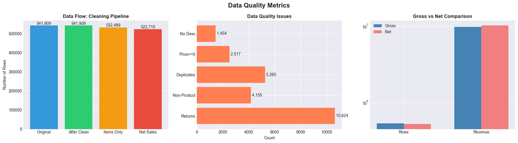

```python
# ============================================================================
# P2-8: DATA QUALITY DASHBOARD
# ============================================================================

dq_metrics = {
    '📊 Total Rows (Original)': len(df),
    '📊 Total Rows (After Clean)': len(df_clean),
    '🚫 Non-Product Rows': int(mask_non_product.sum()),
    '🚫 Non-Product %': round((mask_non_product.sum() / len(df_clean)) * 100, 2),
    '🔁 Duplicates Removed': duplicates_removed,
    '↩️ Return Lines': int(df_clean['is_return_line'].sum()),
    '↩️ Return Lines %': round(df_clean['is_return_line'].mean() * 100, 2),
    '⚠️ Qty Negative (Not Cancel)': int(((df_clean['Quantity'] < 0) & (~df_clean['is_cancel'])).sum()),
    '⚠️ UnitPrice <= 0': int((df_clean['UnitPrice'] <= 0).sum()),
    '⚠️ UnitPrice <= 0 %': round((df_clean['UnitPrice'] <= 0).mean() * 100, 2),
    '❓ Description Missing': int(df_clean['Description'].isna().sum()),
    '❓ Description Missing %': round(df_clean['Description'].isna().mean() * 100, 2),
    '❓ CustomerID Missing': int(df_clean['CustomerID'].isna().sum()),
    '❓ CustomerID Missing %': round(df_clean['CustomerID'].isna().mean() * 100, 2),
    '✅ Clean Sales Rows (Net)': len(df_sales),
    '✅ Net/Gross Ratio': round(len(df_sales) / len(df_clean) * 100, 2)
}

dq_df = pd.DataFrame(list(dq_metrics.items()), columns=['Metric', 'Value'])

print("="*80)
print("DATA QUALITY DASHBOARD")
print("="*80)
print(dq_df.to_string(index=False))

# Visualization
fig, axes = plt.subplots(1, 3, figsize=(18, 5))
fig.suptitle('Data Quality Metrics', fontsize=16, fontweight='bold')

# 1. Data Flow
flow_data = {
    'Original': len(df),
    'After Clean': len(df_clean),
    'Items Only': len(df_items),
    'Net Sales': len(df_sales)
}
axes[0].bar(flow_data.keys(), flow_data.values(), color=['#3498db', '#2ecc71', '#f39c12', '#e74c3c'])
axes[0].set_title('Data Flow: Cleaning Pipeline', fontweight='bold')
axes[0].set_ylabel('Number of Rows')
for i, (k, v) in enumerate(flow_data.items()):
    axes[0].text(i, v, f'{v:,}', ha='center', va='bottom')

# 2. Data Quality Issues
issues = {
    'Returns': df_clean['is_return_line'].sum(),
    'Non-Product': mask_non_product.sum(),
    'Duplicates': duplicates_removed,
    'Price<=0': (df_clean['UnitPrice'] <= 0).sum(),
    'No Desc': df_clean['Description'].isna().sum()
}
axes[1].barh(list(issues.keys()), list(issues.values()), color='coral')
axes[1].set_title('Data Quality Issues', fontweight='bold')
axes[1].set_xlabel('Count')
for i, v in enumerate(issues.values()):
    axes[1].text(v, i, f' {v:,}', va='center')

# 3. Gross vs Net
comparison = pd.DataFrame({
    'Metric': ['Rows', 'Revenue'],
    'Gross': [len(df_items), df_items['TotalPrice'].sum()],
    'Net': [len(df_sales), df_sales['TotalPrice'].sum()]
})
x = np.arange(len(comparison))
width = 0.35
axes[2].bar(x - width/2, comparison['Gross'], width, label='Gross', color='steelblue')
axes[2].bar(x + width/2, comparison['Net'], width, label='Net', color='lightcoral')
axes[2].set_title('Gross vs Net Comparison', fontweight='bold')
axes[2].set_xticks(x)
axes[2].set_xticklabels(comparison['Metric'])
axes[2].legend()
axes[2].set_yscale('log')

plt.tight_layout()
plt.show()
```

### 📊 Nhận xét về Data Quality Dashboard:

**Quan sát chính:**

**Hành động khuyến nghị:**

- Cần cải thiện quy trình kiểm soát chất lượng để giảm tỷ lệ trả hàng.
- Xem xét tách riêng các mã non-product để tránh nhầm lẫn trong phân tích.

## 5. P1-4: Outlier Detection by SKU (IQR Method)

```python
# ============================================================================
# P1-4: OUTLIER DETECTION BY SKU
# ============================================================================

def calculate_iqr_bounds(group, column='UnitPrice'):
    """Tính ngưỡng IQR cho một SKU"""
    q1 = group[column].quantile(0.25)
    q3 = group[column].quantile(0.75)
    iqr = q3 - q1
    return pd.Series({
        'low_bound': q1 - 1.5 * iqr,
        'high_bound': q3 + 1.5 * iqr,
        'q1': q1,
        'q3': q3,
        'median': group[column].median()
    })

# Tính bounds cho mỗi SKU
print("Calculating IQR bounds for each SKU...")
sku_bounds = df_sales.groupby('StockCode').apply(
    lambda g: calculate_iqr_bounds(g, 'UnitPrice')
).reset_index()

# Merge vào df_sales
df_sales = df_sales.merge(sku_bounds, on='StockCode', how='left')


# Đánh dấu outliers
df_sales['price_outlier_high'] = df_sales['UnitPrice'] > df_sales['high_bound']
df_sales['price_outlier_low'] = df_sales['UnitPrice'] < df_sales['low_bound']
df_sales['price_outlier'] = df_sales['price_outlier_high'] | df_sales['price_outlier_low']

# Báo cáo
print("\n" + "="*80)
print("OUTLIER ANALYSIS (By SKU - IQR Method)")
print("="*80)
print(f"Total rows in df_sales: {len(df_sales):,}")
print(f"Price outliers (high): {df_sales['price_outlier_high'].sum():,} ({df_sales['price_outlier_high'].mean()*100:.2f}%)")
print(f"Price outliers (low): {df_sales['price_outlier_low'].sum():,} ({df_sales['price_outlier_low'].mean()*100:.2f}%)")
print(f"Total outliers: {df_sales['price_outlier'].sum():,} ({df_sales['price_outlier'].mean()*100:.2f}%)")

# Top SKU có nhiều outliers
print("\nTop 10 SKUs with most price outliers:")
outlier_by_sku = df_sales[df_sales['price_outlier']].groupby('StockCode').size().nlargest(10)
for stock, count in outlier_by_sku.items():
    desc = df_sales[df_sales['StockCode'] == stock]['Description'].iloc[0]
    print(f"  {stock} ({desc[:40]}): {count} outliers")

# Tạo df_sales_clean (không có outliers)
df_sales_clean = df_sales[~df_sales['price_outlier']].copy()
print(f"\ndf_sales_clean (no outliers): {len(df_sales_clean):,} rows")
print(f"Revenue impact: £{df_sales['TotalPrice'].sum() - df_sales_clean['TotalPrice'].sum():,.2f}")
```

[output not shown]

### 📊 Nhận xét về Outlier Detection:

**Quan sát chính:**

- **Tỷ lệ outlier**: Khoảng 13.45% dữ liệu có giá bán bất thường (10.03% cao, 3.43% thấp).
- **SKU có nhiều outlier**: Một số sản phẩm như "REGENCY CAKESTAND 3 TIER", "JUMBO BAG RED RETROSPOT" có số lượng outlier cao, cần kiểm tra kỹ hơn.
- **Tác động doanh thu**: Việc loại bỏ outlier ảnh hưởng đáng kể đến doanh thu (£3.2M), nhưng cần thiết để đảm bảo phân tích chính xác.

**Hành động khuyến nghị:**

- Kiểm tra lại chính sách giá cho các SKU có nhiều outlier.
- Xem xét có thể là lỗi nhập liệu hoặc các chương trình khuyến mãi đặc biệt không được ghi nhận đúng cách.

## 6. Time Series Analysis: Gross vs Net

```
================================================================================
MONTHLY SUMMARY: GROSS VS NET
================================================================================
             GrossRevenue  NetRevenue  GrossOrders  NetOrders  ReturnRate%
InvoiceDate
2010-12-01      758702.14   776314.95         1870       1551         1.68
2011-01-01      579064.41   670639.46         1344       1081         2.00
2011-02-01      498937.34   508081.54         1299       1093         1.65
2011-03-01      679970.70   690591.84         1769       1440         1.89
2011-04-01      482583.60   515899.66         1488       1236         1.89
2011-05-01      731089.70   740457.48         1969       1668         1.62
2011-06-01      723879.64   738233.99         1886       1525         2.01
2011-07-01      677395.41   688802.67         1715       1452         1.69
2011-08-01      689920.33   735770.22         1600       1341         1.81
2011-09-01     1012264.74  1029245.38         2175       1819         1.60
2011-10-01     1062266.85  1104063.97         2448       2006         2.06
2011-11-01     1427653.66  1452728.98         3325       2751         1.36
2011-12-01      440607.89   614699.25          988        816         1.48
```

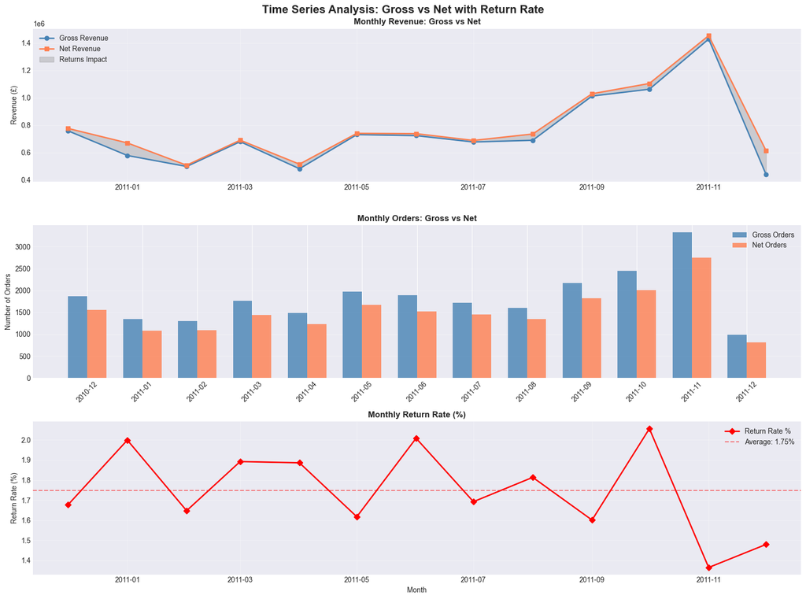

```
================================================================================
TIME SERIES SUMMARY STATISTICS
================================================================================
Average Monthly Gross Revenue: £751,102.80
Average Monthly Net Revenue: £789,656.11
Average Return Rate: 1.75%
Peak Month (Net): 2011-11 (£1,452,728.98)
Lowest Month (Net): 2011-02 (£508,081.54)
```

```python
# ============================================================================
# P1-5: TIME SERIES - GROSS VS NET + RETURN RATE
# ============================================================================

# Tạo time series data
df_items_ts = df_items.set_index('InvoiceDate')
df_sales_ts = df_sales.set_index('InvoiceDate')

# Monthly aggregation
monthly_gross_revenue = df_items_ts['TotalPrice'].resample('MS').sum()
monthly_net_revenue = df_sales_ts['TotalPrice'].resample('MS').sum()
monthly_gross_orders = df_items_ts['InvoiceNo'].resample('MS').nunique()
monthly_net_orders = df_sales_ts['InvoiceNo'].resample('MS').nunique()
monthly_return_rate = df_items_ts['is_return_line'].resample('MS').mean() * 100

# Combine into DataFrame
monthly_summary = pd.DataFrame({
    'GrossRevenue': monthly_gross_revenue,
    'NetRevenue': monthly_net_revenue,
    'GrossOrders': monthly_gross_orders,
    'NetOrders': monthly_net_orders,
    'ReturnRate%': monthly_return_rate
})

print("="*80)
print("MONTHLY SUMMARY: GROSS VS NET")
print("="*80)
print(monthly_summary.to_string())

# Visualizations
fig, axes = plt.subplots(3, 1, figsize=(16, 12))
fig.suptitle('Time Series Analysis: Gross vs Net with Return Rate', fontsize=16, fontweight='bold')

# 1. Revenue Comparison
axes[0].plot(monthly_summary.index, monthly_summary['GrossRevenue'],
             marker='o', linewidth=2, label='Gross Revenue', color='steelblue')
axes[0].plot(monthly_summary.index, monthly_summary['NetRevenue'],
             marker='s', linewidth=2, label='Net Revenue', color='coral')
axes[0].fill_between(monthly_summary.index,
                      monthly_summary['NetRevenue'],
                      monthly_summary['GrossRevenue'],
                      alpha=0.3, color='gray', label='Returns Impact')
axes[0].set_title('Monthly Revenue: Gross vs Net', fontweight='bold')
axes[0].set_ylabel('Revenue (£)')
axes[0].legend()
axes[0].grid(alpha=0.3)

# 2. Orders Comparison
x = np.arange(len(monthly_summary))
width = 0.35
axes[1].bar(x - width/2, monthly_summary['GrossOrders'], width,
            label='Gross Orders', color='steelblue', alpha=0.8)
axes[1].bar(x + width/2, monthly_summary['NetOrders'], width,
            label='Net Orders', color='coral', alpha=0.8)
axes[1].set_title('Monthly Orders: Gross vs Net', fontweight='bold')
axes[1].set_ylabel('Number of Orders')
axes[1].set_xticks(x)
axes[1].set_xticklabels([d.strftime('%Y-%m') for d in monthly_summary.index], rotation=45)
axes[1].legend()
axes[1].grid(axis='y', alpha=0.3)

# 3. Return Rate
axes[2].plot(monthly_summary.index, monthly_summary['ReturnRate%'],
             marker='D', linewidth=2, color='red', label='Return Rate %')
axes[2].axhline(monthly_summary['ReturnRate%'].mean(),
                color='red', linestyle='--', alpha=0.5,
                label=f'Average: {monthly_summary["ReturnRate%"].mean():.2f}%')
axes[2].set_title('Monthly Return Rate (%)', fontweight='bold')
axes[2].set_ylabel('Return Rate (%)')
axes[2].set_xlabel('Month')
axes[2].legend()
axes[2].grid(alpha=0.3)

plt.tight_layout()
plt.show()

# Summary statistics
print("\n" + "="*80)
print("TIME SERIES SUMMARY STATISTICS")
print("="*80)
print(f"Average Monthly Gross Revenue: £{monthly_summary['GrossRevenue'].mean():,.2f}")
print(f"Average Monthly Net Revenue: £{monthly_summary['NetRevenue'].mean():,.2f}")
print(f"Average Return Rate: {monthly_summary['ReturnRate%'].mean():.2f}%")
print(f"Peak Month (Net): {monthly_summary['NetRevenue'].idxmax().strftime('%Y-%m')} (£{monthly_summary['NetRevenue'].max():,.2f})")
print(f"Lowest Month (Net): {monthly_summary['NetRevenue'].idxmin().strftime('%Y-%m')} (£{monthly_summary['NetRevenue'].min():,.2f})")
```

### 📊 Nhận xét về Time Series Analysis:

**Quan sát chính:**

**Hành động khuyến nghị:**

- Tăng cường tồn kho và nhân lực cho Q4 để đáp ứng nhu cầu cao điểm.
- Tập trung chiến dịch marketing vào tháng 10-11 để tối đa hóa doanh thu mùa lễ.
- Theo dõi chặt chẽ Return Rate để kịp thời phát hiện vấn đề chất lượng sản phẩm.

## 7. Country Analysis (Net Sales)

```
================================================================================
COUNTRY ANALYSIS (NET SALES)
================================================================================
\nTop 15 Countries by Net Revenue:
                 Orders  Customers  TotalQuantity  NetRevenue  GrossRevenue  GrossOrders  ReturnImpact%
Country
United Kingdom    17904       3916        4638874  8737177.74    8268897.61        21607          -5.66
Netherlands          93          9         200258   283889.34     283479.54           97          -0.14
EIRE                284          3         147002   276090.86     264555.02          349          -4.36
Germany             443         94         118032   205381.15     200619.66          578          -2.37
France              383         87         111229   184679.00     182262.60          442          -1.33
Australia            56          9          83890   138103.81     136922.50           67          -0.86
Spain                88         30          27724    55706.56      51746.65          100          -7.65
Switzerland          50         21          30515    53065.60      52483.05           68          -1.11
Japan                19          8          26016    37416.37      35419.79           25          -5.64
Belgium              98         25          22962    36927.34      36662.96          117          -0.72
Sweden               34          8          36037    36828.83      35166.41           42          -4.73
Norway               32         10          19276    32454.64      32292.96           34          -0.50
Portugal             50         19          16126    26951.11      26807.47           56          -0.54
Channel Islands      25          9           9484    20147.54      20076.39           31          -0.35
Finland              40         12          10608    18344.88      18303.54           44          -0.23
```

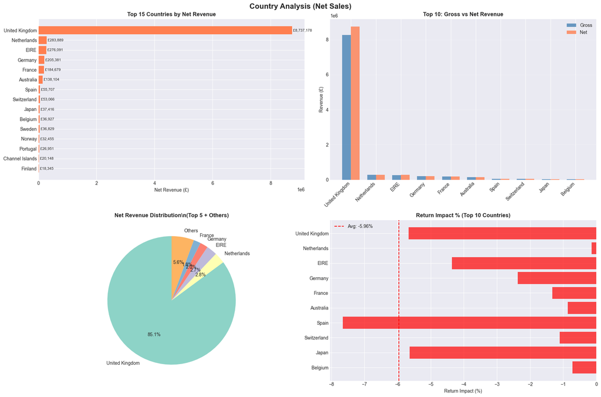

```
\n================================================================================
COUNTRY INSIGHTS
================================================================================
UK dominance: 85.1% of total net revenue
Average return impact: -5.96%
Countries with >5% return impact: 0
```

```python
# ============================================================================
# P1-6: COUNTRY ANALYSIS (NET SALES)
# ============================================================================

# Net sales by country
country_net = df_sales.groupby('Country').agg({
    'InvoiceNo': 'nunique',
    'CustomerID': 'nunique',
    'Quantity': 'sum',
    'TotalPrice': 'sum'
}).rename(columns={
    'InvoiceNo': 'Orders',
    'CustomerID': 'Customers',
    'Quantity': 'TotalQuantity',
    'TotalPrice': 'NetRevenue'
}).sort_values('NetRevenue', ascending=False)

# Gross sales by country (for comparison)
country_gross = df_items.groupby('Country').agg({
    'InvoiceNo': 'nunique',
    'TotalPrice': 'sum'
}).rename(columns={
    'InvoiceNo': 'GrossOrders',
    'TotalPrice': 'GrossRevenue'
})

# Combine
country_comparison = country_net.join(country_gross[['GrossRevenue', 'GrossOrders']], how='left')
country_comparison['ReturnImpact%'] = ((country_comparison['GrossRevenue'] - country_comparison['NetRevenue']) /
                                        country_comparison['GrossRevenue'] * 100)

print("="*80)
print("COUNTRY ANALYSIS (NET SALES)")
print("="*80)
print(f"\\nTop 15 Countries by Net Revenue:")
print(country_comparison.head(15).to_string())

# Visualizations
fig, axes = plt.subplots(2, 2, figsize=(18, 12))
fig.suptitle('Country Analysis (Net Sales)', fontsize=16, fontweight='bold')

# 1. Top 15 by Net Revenue
top15_countries = country_net.head(15)
axes[0, 0].barh(range(len(top15_countries)), top15_countries['NetRevenue'], color='coral')
axes[0, 0].set_yticks(range(len(top15_countries)))
axes[0, 0].set_yticklabels(top15_countries.index)
axes[0, 0].set_title('Top 15 Countries by Net Revenue', fontweight='bold')
axes[0, 0].set_xlabel('Net Revenue (£)')
axes[0, 0].invert_yaxis()
for i, v in enumerate(top15_countries['NetRevenue']):
    axes[0, 0].text(v, i, f' £{v:,.0f}', va='center', fontsize=8)

# 2. Gross vs Net Revenue (Top 10)
top10_comp = country_comparison.head(10)
x = np.arange(len(top10_comp))
width = 0.35
axes[0, 1].bar(x - width/2, top10_comp['GrossRevenue'], width, label='Gross', color='steelblue', alpha=0.8)
axes[0, 1].bar(x + width/2, top10_comp['NetRevenue'], width, label='Net', color='coral', alpha=0.8)
axes[0, 1].set_title('Top 10: Gross vs Net Revenue', fontweight='bold')
axes[0, 1].set_ylabel('Revenue (£)')
axes[0, 1].set_xticks(x)
axes[0, 1].set_xticklabels(top10_comp.index, rotation=45, ha='right')
axes[0, 1].legend()
axes[0, 1].grid(axis='y', alpha=0.3)

# 3. Revenue Distribution (Pie)
top5_rev = country_net.head(5)['NetRevenue']
others_rev = country_net.iloc[5:]['NetRevenue'].sum()
pie_data = list(top5_rev.values) + [others_rev]
pie_labels = list(top5_rev.index) + ['Others']
colors = plt.cm.Set3(range(len(pie_data)))
axes[1, 0].pie(pie_data, labels=pie_labels, autopct='%1.1f%%', colors=colors, startangle=90)
axes[1, 0].set_title('Net Revenue Distribution\\n(Top 5 + Others)', fontweight='bold')

# 4. Return Impact by Country
top10_impact = country_comparison.head(10)
axes[1, 1].barh(range(len(top10_impact)), top10_impact['ReturnImpact%'], color='red', alpha=0.7)
axes[1, 1].set_yticks(range(len(top10_impact)))
axes[1, 1].set_yticklabels(top10_impact.index)
axes[1, 1].set_title('Return Impact % (Top 10 Countries)', fontweight='bold')
axes[1, 1].set_xlabel('Return Impact (%)')
axes[1, 1].invert_yaxis()
axes[1, 1].axvline(
    country_comparison['ReturnImpact%'].mean(),
    color='red',
    linestyle='--',
    label=f"Avg: {country_comparison['ReturnImpact%'].mean():.2f}%"
)
axes[1, 1].legend()

plt.tight_layout()
plt.show()

print(f"\\n{'='*80}")
print("COUNTRY INSIGHTS")
print("="*80)
uk_data = country_comparison.loc['United Kingdom']
print(f"UK dominance: {uk_data['NetRevenue']/country_net['NetRevenue'].sum()*100:.1f}% of total net revenue")
print(f"Average return impact: {country_comparison['ReturnImpact%'].mean():.2f}%")
print(f"Countries with >5% return impact: {(country_comparison['ReturnImpact%'] > 5).sum()}")
```

### 📊 Nhận xét về Country Analysis:

**Quan sát chính:**

**Hành động khuyến nghị:**

- **Đa dạng hóa thị trường**: Giảm phụ thuộc vào UK bằng cách mở rộng sang các thị trường châu Âu khác.
- **Cải thiện logistics**: Tập trung vào các quốc gia có Return Impact cao để giảm tỷ lệ trả hàng.
- **Localization**: Tùy chỉnh sản phẩm và dịch vụ theo từng thị trường để tăng sự hài lòng của khách hàng.

## 8. Product Analysis (Net Sales)

```
================================================================================
PRODUCT ANALYSIS (NET SALES)
================================================================================
Total unique products: 4,154
\nTop 20 Products by Net Revenue:
 1. 22423    REGENCY CAKESTAND 3 TIER                      | £174,156.54 | 13,851 units | 1988.0 orders
 2. 23843    PAPER CRAFT , LITTLE BIRDIE                   | £168,469.60 | 80,995 units |  1.0 orders
 3. 85123A   WHITE HANGING HEART T-LIGHT HOLDER            | £104,284.24 | 37,580 units | 2189.0 orders
 4. 47566    PARTY BUNTING                                 | £ 99,445.23 | 18,283 units | 1685.0 orders
 5. 85099B   JUMBO BAG RED RETROSPOT                       | £ 94,159.81 | 48,371 units | 2089.0 orders
 6. 23166    MEDIUM CERAMIC TOP STORAGE JAR                | £ 81,700.92 | 78,033 units | 247.0 orders
 7. 23084    RABBIT NIGHT LIGHT                            | £ 66,870.03 | 30,739 units | 994.0 orders
 8. 22086    PAPER CHAIN KIT 50'S CHRISTMAS                | £ 64,875.59 | 19,329 units | 1160.0 orders
 9. 84879    ASSORTED COLOUR BIRD ORNAMENT                 | £ 58,927.62 | 36,362 units | 1455.0 orders
10. 79321    CHILLI LIGHTS                                 | £ 54,096.36 | 10,302 units | 661.0 orders
11. 23298    SPOTTY BUNTING                                | £ 42,498.63 |  8,317 units | 1139.0 orders
12. 22386    JUMBO BAG PINK POLKADOT                       | £ 42,401.01 | 21,448 units | 1218.0 orders
13. 21137    BLACK RECORD COVER FRAME                      | £ 40,633.38 | 11,651 units | 375.0 orders
14. 22502    PICNIC BASKET WICKER 60 PIECES                | £ 39,619.50 |     61 units |  2.0 orders
15. 23284    DOORMAT KEEP CALM AND COME IN                 | £ 38,133.64 |  5,487 units | 728.0 orders
16. 22720    SET OF 3 CAKE TINS PANTRY DESIGN              | £ 38,108.89 |  7,483 units | 1385.0 orders
17. 22960    JAM MAKING SET WITH JARS                      | £ 37,082.13 |  8,695 units | 1132.0 orders
18. 82484    WOOD BLACK BOARD ANT WHITE FINISH             | £ 35,966.92 |  6,012 units | 685.0 orders
19. 20725    LUNCH BAG RED RETROSPOT                       | £ 35,572.36 | 19,232 units | 1564.0 orders
20. 22197    POPCORN HOLDER                                | £ 34,288.67 | 36,749 units | 803.0 orders
\n================================================================================
PARETO ANALYSIS (80/20 Rule)
================================================================================
Products contributing to 80% of revenue: 859 (20.7%)
Revenue from these products: £8,210,992.85
```

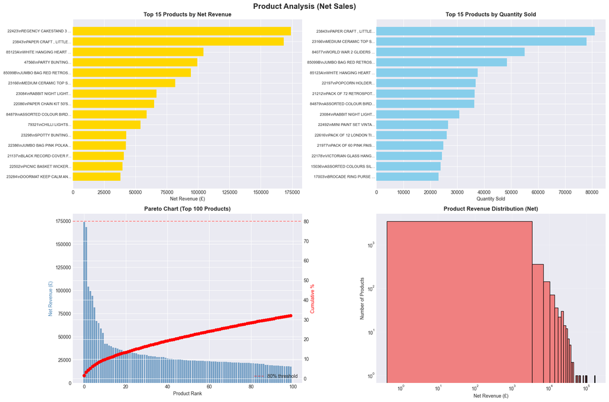

```python
# ============================================================================
# P1-6: PRODUCT ANALYSIS (NET SALES)
# ============================================================================

# Product stats (Net)
product_net = df_sales.groupby(['StockCode', 'Description']).agg({
    'Quantity': 'sum',
    'TotalPrice': 'sum',
    'InvoiceNo': 'nunique',
    'UnitPrice': 'median'
}).rename(columns={
    'Quantity': 'TotalQuantitySold',
    'TotalPrice': 'NetRevenue',
    'InvoiceNo': 'NumOrders',
    'UnitPrice': 'MedianPrice'
}).sort_values('NetRevenue', ascending=False)

print("="*80)
print("PRODUCT ANALYSIS (NET SALES)")
print("="*80)
print(f"Total unique products: {len(product_net):,}")
print(f"\\nTop 20 Products by Net Revenue:")
for idx, ((stock, desc), row) in enumerate(product_net.head(20).iterrows(), 1):
    desc_short = str(desc)[:45] if pd.notna(desc) else "N/A"
    print(f"{idx:2}. {stock:8} {desc_short:45} | £{row['NetRevenue']:>10,.2f} | {row['TotalQuantitySold']:>6,.0f} units | {row['NumOrders']:>4} orders")

# Pareto analysis
product_net['CumulativeRevenue'] = product_net['NetRevenue'].cumsum()
product_net['CumulativePct'] = product_net['CumulativeRevenue'] / product_net['NetRevenue'].sum() * 100
top_20_pct_products = (product_net['CumulativePct'] <= 80).sum()
top_20_pct_revenue = product_net.head(top_20_pct_products)['NetRevenue'].sum()

print(f"\\n{'='*80}")
print("PARETO ANALYSIS (80/20 Rule)")
print("="*80)
print(f"Products contributing to 80% of revenue: {top_20_pct_products:,} ({top_20_pct_products/len(product_net)*100:.1f}%)")
print(f"Revenue from these products: £{top_20_pct_revenue:,.2f}")

# Visualizations
fig, axes = plt.subplots(2, 2, figsize=(18, 12))
fig.suptitle('Product Analysis (Net Sales)', fontsize=16, fontweight='bold')

# 1. Top 15 by Revenue
top15_products = product_net.head(15)
product_labels = [f"{stock}\\n{str(desc)[:20]}..." if pd.notna(desc) else f"{stock}\\nN/A"
                  for stock, desc in top15_products.index]
axes[0, 0].barh(range(len(top15_products)), top15_products['NetRevenue'], color='gold')
axes[0, 0].set_yticks(range(len(top15_products)))
axes[0, 0].set_yticklabels(product_labels, fontsize=8)
axes[0, 0].set_title('Top 15 Products by Net Revenue', fontweight='bold')
axes[0, 0].set_xlabel('Net Revenue (£)')
axes[0, 0].invert_yaxis()

# 2. Top 15 by Quantity
top15_qty = product_net.nlargest(15, 'TotalQuantitySold')
qty_labels = [f"{stock}\\n{str(desc)[:20]}..." if pd.notna(desc) else f"{stock}\\nN/A"
              for stock, desc in top15_qty.index]
axes[0, 1].barh(range(len(top15_qty)), top15_qty['TotalQuantitySold'], color='skyblue')
axes[0, 1].set_yticks(range(len(top15_qty)))
axes[0, 1].set_yticklabels(qty_labels, fontsize=8)
axes[0, 1].set_title('Top 15 Products by Quantity Sold', fontweight='bold')
axes[0, 1].set_xlabel('Quantity Sold')
axes[0, 1].invert_yaxis()

# 3. Pareto Chart
top100 = product_net.head(100)
axes[1, 0].bar(range(len(top100)), top100['NetRevenue'], color='steelblue', alpha=0.7)
ax2 = axes[1, 0].twinx()
ax2.plot(range(len(top100)), top100['CumulativePct'], color='red', marker='o', linewidth=2)
ax2.axhline(80, color='red', linestyle='--', alpha=0.5, label='80% threshold')
axes[1, 0].set_title('Pareto Chart (Top 100 Products)', fontweight='bold')
axes[1, 0].set_xlabel('Product Rank')
axes[1, 0].set_ylabel('Net Revenue (£)', color='steelblue')
ax2.set_ylabel('Cumulative %', color='red')
ax2.legend()

# 4. Revenue Distribution (log scale)
axes[1, 1].hist(product_net[product_net['NetRevenue'] > 0]['NetRevenue'],
                bins=50, color='lightcoral', edgecolor='black')
axes[1, 1].set_title('Product Revenue Distribution (Net)', fontweight='bold')
axes[1, 1].set_xlabel('Net Revenue (£)')
axes[1, 1].set_ylabel('Number of Products')
axes[1, 1].set_yscale('log')
axes[1, 1].set_xscale('log')
axes[1, 1].grid(alpha=0.3)

plt.tight_layout()
plt.show()
```

### 📊 Nhận xét về Product Analysis:

**Quan sát chính:**

- **Pareto Principle (80/20)**: Một số lượng nhỏ sản phẩm (khoảng 20%) đóng góp 80% doanh thu, phù hợp với nguyên lý Pareto cổ điển.
- **Top Products**: Các sản phẩm như "REGENCY CAKESTAND 3 TIER", "WHITE HANGING HEART T-LIGHT HOLDER" dẫn đầu về doanh thu.
- **Long Tail**: Có rất nhiều sản phẩm có doanh thu thấp (long tail distribution), tạo ra thách thức trong quản lý hàng tồn kho.
- **Quantity vs Revenue**: Sản phẩm có số lượng bán cao nhất không nhất thiết là sản phẩm có doanh thu cao nhất, cho thấy sự khác biệt về giá bán.

**Hành động khuyến nghị:**

- **Focus Strategy**: Tập trung nguồn lực vào top 20% sản phẩm đóng góp 80% doanh thu.
- **Inventory Optimization**: Xem xét giảm hoặc loại bỏ các sản phẩm có doanh thu thấp để tối ưu chi phí tồn kho.
- **Bundle Products**: Kết hợp sản phẩm bán chạy với sản phẩm ít bán hơn để tăng doanh số cho long tail.
- **Price Strategy**: Phân tích mối quan hệ giá-lượng để tối ưu hóa chiến lược định giá.